# Assignment 4: Movie Review Analysis [50 Pt]

In this assignment, we will build a recurrent neural network to work with sequential text data, specificially, movie review data to identify the reviewer sentiment. In the process of completing this assignment, you will:

1. Clean and process text data for machine learning.
2. Perform tokenization of text data.
3. Understand and implement a word-level recurrent neural network.
4. Implement batching of text data using a DataLoader before training a recurrent neural network.
5. Understand how to apply pretrained models for transfer learning in natural language processing projects.

### What to submit

Submit an HTML file and an IPYNB file containing all your code, outputs, and write-up from parts A and B. You can produce a HTML file directly from Google Colab. The Colab instructions are provided at the end of this document.

Include a link to your colab file in your submission.

Please use Google Colab to complete this assignment. If you want to use Jupyter Notebook, please complete the assignment and upload your Jupyter Notebook file to Google Colab for submission.

## Colab Link

Include a link to your Colab file here. If you would like the TA to look at your Colab file in case your solutions are cut off, **please make sure that your Colab file is publicly accessible at the time of submission.**

```python
# TO BE COMPLETED

# http://https://colab.research.google.com/drive/11Ci0q7TkYKO07HFMYDXq-faTE83_rupe
```

# PART A - Sentiment Analysis

In this part we will construct a world-level LSTM model for identifying positive and negative reviews. This will be done in a similar way to what was shared in the preparation code for Assignment 4.

```python
# load standard modules/libraries
import pandas as pd
import numpy as np
import matplotlib.pyplot as plt
import seaborn as sns
from sklearn.model_selection import train_test_split

# load special modules/libraries
import os
import warnings
import nltk
from nltk.corpus import stopwords
nltk.download('stopwords')

from collections import Counter
import string
import re
from tqdm  import tqdm

# load pytorch modules/libraries
import torch
import torch.nn as nn
import torch.nn.functional as F
import torch.optim as optim
from torch.utils.data import TensorDataset,DataLoader

import csv
import warnings
warnings.filterwarnings('ignore')
```

## Part 1. Data Cleaning [5 pt]

We will be using the "IMDB Movie Review Dataset" provided on the course website. Download "IMDB Dataset.csv" into your Colab workspace.

### Part (i) [1pt EXPLORATORY]

Open up the file in Python, and examine some examples of positive and negative reviews. Comment on the quality of the data and any challenges you foresee in working with these data. Pick one example of a positive review and one of a negative review to support your comments.

```python
# download IMDB review data

# load dataset
df = pd.read_csv("IMDB Dataset.csv")

# process into data and labels
X = df['review'].values
y = df['sentiment'].values
```

```python
# TO BE COMPLETED
df.head(100)
```

|  | review | sentiment |
| --- | --- | --- |
| 0 | I really liked this Summerslam due to the look... | positive |
| 1 | Not many television shows appeal to quite as m... | positive |
| 2 | The film quickly gets to a major chase scene w... | negative |
| 3 | Jane Austen would definitely approve of this o... | positive |
| 4 | Expectations were somewhat high for me when I ... | negative |
| ... | ... | ... |
| 95 | I walked into the movie theater, with no expec... | positive |
| 96 | Buster Keaton was arguably at his most enjoyab... | positive |
| 97 | A beautiful woman, a backwoods, inbred monster... | positive |
| 98 | Ok, even if you can't stand Liza- this movie i... | positive |
| 99 | This was on at 2 or so In the morning one Satu... | positive |

100 rows × 2 columns

```python
# Challenge 1 - Length Variance
neg_review_1 = df.loc[28][0]
pos_review_1 =df.loc[98][0]

print(
    "===Challenge 1 - Length Variance===\n"
    f"Length of a negative review: {len(neg_review_1)}\n"
    f"Length of a positive review: {len(pos_review_1)}\n"
)

# Challenge 2 - HTML type characters Noise
neg_review_2 = df.loc[12][0]
print("===Challenge 2 - HTML type characters===\n","...",neg_review_2[200:300],"...\n")

# Challenge 3 - Multiple Sentiment in 1 review
pos_review_2 = df.loc[3][0]
print("===Challenge 3 - Multiple Sentiment in 1 review===\n",pos_review_2,"\n")

# Challenge 4 - Emoticon
neg_review_3 = df.loc[8][0]
print("===Challenge 4 - Emoticon===\n",neg_review_3[-3:])
```

```
===Challenge 1 - Length Variance===
Length of a negative review: 5152
Length of a positive review: 304

===Challenge 2 - HTML type characters===
 ... k on the CG stuff look even worse.<br /><br />The writing, acting, directing and everything else in  ...

===Challenge 3 - Multiple Sentiment in 1 review===
 Jane Austen would definitely approve of this one!<br /><br />Gwyneth Paltrow does an awesome job capturing the attitude of Emma. She is funny without being excessively silly, yet elegant. She puts on a very convincing British accent (not being British myself, maybe I'm not the best judge, but she f…

===Challenge 4 - Emoticon===
 :-(
```

```python
'''
PROVIDE YOUR ANSWER BELOW

The general review data quality is good with diversity, but there are some challenges:
  -> Challenge 1: Length Variance - reviews length vary from hundruds of characters to a dozen of thousands of characters, which may affect the model to get the most useful information. I need to average out the length or remove the unnecessary content
  -> Challenge 2: HTML type characters Noise- reviews extracted from websites still keep HTML characters like "<br>. I need to apply regularization to clean data
  -> Challenge 3: Multiple Sentiment in 1 review - some reviews have both positive and negative feelings, will be a risk for model to understand
  -> Challenge 4 - Emoticon - Could be a challenge for model to understand such unusual characters

'''
```

### Part (ii) [1pt EXPLORATORY]

Perform summary statistics on the dataset. What is the average word count of a review? What are the word counts of the longest and shortest reviews?

How many positive reviews and negative reviews are there. Generate a histogram to compare the distribution of word counts for positive and negative reviews. Comment on the differences in positive and negative reviews and how that may affect the model you will be using later.

```
Average word count of a review: 258
Word counts of the longest review: 2667
Word counts of the shortest review: 7

Sentiment Conut:
 sentiment
positive    20004
negative    19996
Name: count, dtype: int64
```

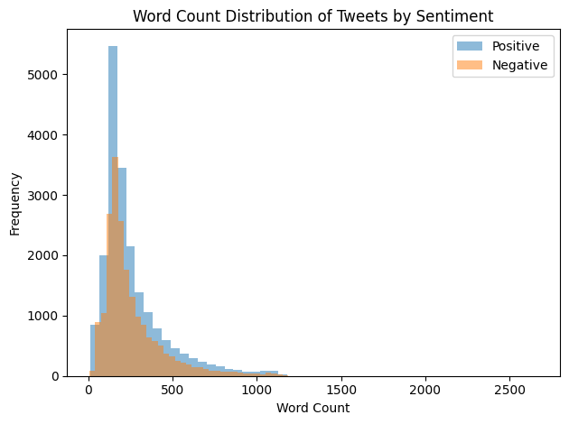

```python
# TO BE COMPLETED

# ---- word split ----
def split_tweet(tweet):
    # separate punctuations
    tweet = tweet.replace(".", " . ") \
                 .replace(",", " , ") \
                 .replace(";", " ; ") \
                 .replace("?", " ? ")
    return tweet.lower().split()

df['word_count']=df['review'].apply(lambda x: len(split_tweet(x)))


# ---- word counts ----
avg_word_count = int(df['word_count'].mean())
max_word_count = df['word_count'].max()
min_word_count = df['word_count'].min()

print(f"Average word count of a review: {avg_word_count}")
print(f"Word counts of the longest review: {max_word_count}")
print(f"Word counts of the shortest review: {min_word_count}\n")

# ---- Sentiment Conut ----
print("Sentiment Conut:\n",df["sentiment"].value_counts())

# ---- Sentiment Histogram ----
pos_wc_hist = df[df['sentiment']=='positive']['word_count']
neg_wc_hist = df[df['sentiment']=='negative']['word_count']

plt.figure()
plt.hist(pos_wc_hist, bins=50, alpha=0.5, label='Positive')
plt.hist(neg_wc_hist, bins=50, alpha=0.5, label='Negative')
plt.legend(loc='upper center')
plt.xlabel('Word Count')
plt.ylabel('Frequency')
plt.title('Word Count Distribution of Tweets by Sentiment')
plt.legend()
plt.tight_layout()
plt.show()
```

```python
'''
PROVIDE YOUR ANSWER BELOW

Statistics:
Average word count of a review: 258
Word counts of the longest review: 2667
Word counts of the shortest review: 7

Sentiment Conut:
positive    20004
negative    19996


General observations :
Both positive and negative reviews lengths range between 50 and 500 words, the distribution overlappes in the right and less tail, means both have less longer reviews.
The amount of positive and negative reviews are balanced.

Observations positive vs negative:
Because the two distributions almost overlap, the model cannot rely on length alone to guess sentiment, which is good (less trivial shortcut).
Very short reviews (like 7 words) may lack clear sentiment cues, so they are harder cases for both LSTM and BERT.
Very long reviews risk being truncated when we fix a maximum seq_len (e.g., 500 tokens), so for those reviews the model only sees part of the text, which may slightly hurt performance but only for a small fraction of the data.

'''
```